Eerste beweging · Verschil onder de loep

# Hoofdstuk 3 — De grabbelton geschud

De steekproevenverdeling en de standaardfout

> **Bronnen (Bib, transcript):** `analogie-bordjes-spel-sigma-xbar-door-wortel-n-studenten-iq` (het bordjes-spel + theorie-check), `uitleg-drie-verdelingen-populatie-steekproef-steekproevenverdeling` (New York-skyline, canoniek), `uitleg-clt-flauw-grabbelton-lelijke-populatie-toch-normaal-bordjes`, `uitleg-wet-van-grote-aantallen-grotere-n-kleinere-standaardfout`, `berekening-standaardfout-sigma-x-door-wortel-n`. Gat dat dit hoofdstuk dicht: schudden gebeurt hier écht (keukentafel + beeldreeks), niet alleen in de vertelling.

## 1. Het meer

GROF — verhaal-stem, stem-pas volgt. Regels: geen rekwisieten, geen les; de olifant vraagt zich iets af om zijn eigen redenen. De spiraal: H1 zei al “geen slok smaakt als de andere” — nu de omgekeerde vraag.

De olifant stond weer bij het meer.

Hij dronk een slok, en nog een. Toen hield hij zijn slurf stil, halverwege het water en zijn mond.

“Wat is er?” vroeg de meeuw, die op zijn rug zat.

“Ik vroeg me iets af,” zei de olifant. “Ik weet hoe deze slok smaakt. En de vorige. Maar het meer zelf — hoe smaakt het méér?”

De meeuw keek naar het water. Het lag er tot aan de overkant, en om de bocht nog verder, waar je het niet meer kon zien.

“Je zou het leeg moeten drinken,” zei ze.

“Dat lukt me niet,” zei de olifant. “En als het me lukte, was er geen meer meer om naar te smaken.”

Hij dronk nog een slok, een grote dit keer, en hield hem lang in zijn mond.

“Grote slokken,” zei hij langzaam, “lijken meer op elkaar dan kleine slokjes. Heb je dat wel eens gemerkt? Een klein slokje is soms ineens zoet, of ineens modder. Een grote slok is altijd een beetje alles.”

“En het meer?” vroeg de meeuw.

“Het meer is álles,” zei de olifant. “Daarom smaakt een grote slok er meer naar.”

Docent-aansluiting: Wat de olifant hier te pakken heeft, is misschien wel de belangrijkste gedachte van dit hele boek — belangrijker dan elke formule die nog komt. Je kunt het meer niet leegdrinken. Je kunt de werkelijkheid nooit hélemaal meten. Alles wat je ooit in handen krijgt, is een slok. En de vraag is dus nooit “wat is de waarheid?”, maar: **hoe goed vertelt mijn slok mij hoe het meer smaakt?**

Dit hoofdstuk gaat over die vraag. En het rare is: hij is te beantwoorden.

## 2. De ton die nooit leeg raakt

In hoofdstuk 1 grabbelde je uit het schatkistje: twaalf diamantjes, en na twaalf keer pakken had je alles gezien. Dat is wat een onderzoeker in handen heeft — iets eindigs, iets dat je kunt vasthouden en kunt kennen. Het kistje is de *steekproef*.

Maar nu de vraag waar dit hoofdstuk om draait: waar kómen zulke kistjes vandaan?

Uit de ton. En de ton — de *populatie* — raakt nooit leeg. Alle studenten die ooit dit tentamen gaan maken. Alle slokken die je uit het meer zou kunnen nemen. Alle worpen die je ooit met een dobbelsteen zou kunnen doen. Term-blokje: populatie / population. Even-terug: een populatie hoeft geen bestaande verzameling te zijn — vaak is het “alles wat er zou kúnnen zijn”. De ton is een gedachte, en toch kun je eruit trekken.

En kijk nu nog eens naar ons eigen kistje — hoe kwam dat er ook alweer? Het bleef hangen in een beverdam. Denk even na over wat dat betekent. De rivier stroomt, dag en nacht, jaar in jaar uit, en draagt van alles mee — takken, vissen, schoenen, af en toe een kistje. De dam vangt wat er toevallig voorbijkomt. De bever heeft niet gekozen. De rivier heeft niet gekozen. Het kistje bleef gewoon hangen, die ochtend, en niet een ander kistje op een andere ochtend.

*Zo komt elke steekproef aan zijn inhoud.* De rivier is de ton in beweging, en elke dam — elke vragenlijst, elk spreekuur, elke meting op een dinsdagmiddag — vangt wat er die dag langs dreef.

GROF — hier ligt ook een zaadje voor later (selectie/vertekening): een dam vangt niet álles even makkelijk — wat zwaar is zinkt, wat snel is glipt erdoor. Eén teaser-zin hier, uitwerken pas in een later hoofdstuk. Niet uitleggen, alleen laten ruiken.

Uit die onuitputtelijke ton neem jij dus één greep. Eén handvol — één kistje vol. Dat is de verhouding om te onthouden: **een greep uit de ton is een nieuw schatkistje.** En jouw kistje is het enige dat je hebt. Ik noem het graag **de enige echte**: er is er maar één van, en al je kennis moet erdoorheen.

GROF: hier de spanning neerzetten die het hoofdstuk drijft — één greep, en tóch uitspraken over de hele ton willen doen. De olifant met zijn ene slok.

## 3. Gok een bordje

### Het spel, één verdieping omhoog

Terug naar het grabbel-spel van hoofdstuk 1 — er komt een verdieping bovenop.

Toen: jij grabbelde **één diamantje** uit het kistje, en gokte vooraf zijn glans. Beste gok: het gemiddelde (50). En hoe ver je er gemiddeld naast zit, wisten we ook: de standaardafwijking (21.74) — de gemiddelde gokfout.

Nu: ik schud niet het kistje, maar **de ton**. En jij trekt er geen los diamantje uit maar **een hele greep** — een kistje vol, zeg twaalf tegelijk. Je rekent het gemiddelde van je greep uit, schrijft het op een bordje, en komt terug. En ik ga gokken wat er op jouw bordje staat.

> *Je gokt niet langer een diamant. Je gokt een bordje.*

Voel je wat er verschoven is? Het ding dat we voorspellen is geen los geval meer — het is een *samenvatting van een greep*. En net als bij de losse diamantjes zijn er meteen twee vragen: wat is mijn beste gok voor een bordje? En hoe ver zit ik er gemiddeld naast?

GROF — hier het bordjes-spel uit de Bib bijna verbatim laten lopen: “maar misschien kom jij met 112, dan zit je er 2 naast; iemand anders met 107, min 3… en ik wil de gemiddelde afwijking van die bordjes weten.” De SD-taal van H1 tilt zichzelf één niveau op: SD : individu = SE : bordje. Het woord standaardfout valt pas in §5, ná het voelen.

### De keukentafel — twintig keer schudden met je eigen handen

Trede 1 — de lezer is de computer. Docent nodigt de lezer uit; geen dieren in de buurt.

Genoeg gedachte-experiment. Pak vier dobbelstenen. Echt — uit de spelletjeskast, of leen ze. Dit stukje van het boek werkt alleen als je het doet.

De populatie is hier: álle worpen die je ooit met een dobbelsteen zou kunnen doen. Een ton die per definitie nooit leeg raakt. Elke worp van vier dobbelstenen is een greep van $n$ = 4.

1. Gooi de vier dobbelstenen.
2. Reken het gemiddelde uit (optellen, delen door 4 — afronden op kwarten mag).
3. Zet een turfje boven dat getal op de streep hieronder.
4. Doe dit twintig keer.

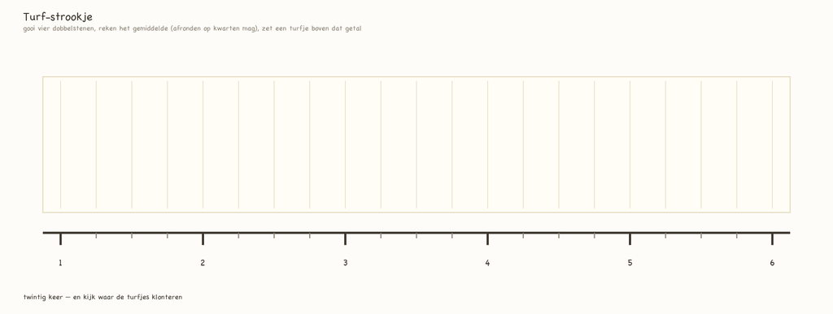

Turf-strookje ingewired (`_bouw_ontbrekend.R`, print-element om ín te schrijven): getallenlijn 1–6 met kwart-kolommen + lege tally-zone. Eindversie kan Bens eigen handtekening worden (Caveat/ruitjes); dit is de warme steiger.

Kijk nu naar twee dingen. Eén: je losse dobbelstenen deden overal wat — enen, zessen, alles even vaak, zo is een dobbelsteen gebouwd. Twee: je *gemiddelden* deden dat niet. Die klonteren. Rond de drieënhalf begint een heuveltje te groeien, en een bordje van 1.0 of 6.0 heb je waarschijnlijk niet één keer gezien — daarvoor moeten alle vier de stenen tegelijk extreem doen, en dat vertikken ze.

Dat heuveltje dat onder je handen groeide, heeft een naam: het is een **steekproevenverdeling** — de verdeling van bordjes. Jij hebt er net één gebouwd. Zonder computer. Onthou wat je zag: *individuen doen wild, gemiddelden doen kalm.*

### De muur van bordjes — van twintig naar altijd

Trede 2 — de beeldreeks. Vier handgetekende panelen: de bordjes-muur bij 20 → 100 → 1.000 → “altijd”. Bij 20: hobbelig turfsel (dat kent de lezer nu van zichzelf). Bij 100: een skyline. Bij 1.000: de skyline strijkt glad. Bij “altijd”: een klok-vorm. GROF: figuur bouwen; de lezer moet de eeuwige herhaling zíén gebeuren, frame voor frame.

In de klas hang ik ze op. Elk bordje dat binnenkomt gaat aan de muur, boven het getal dat erop staat; bordjes met hetzelfde getal komen boven elkaar te hangen. Zo bouwt de muur zichzelf: waar veel bordjes landen groeit een toren, waar zelden een bordje landt blijft de muur kaal. Kijk nog eens naar je turf-strookje van daarnet — dat wás een muur, in het klein: elk turfje een bordje, elke kolom een toren.

Twintig bordjes is geen eeuwigheid. Maar je hebt het begin gezien, en de rest is alleen maar méér van hetzelfde. Stel dat je niet stopt bij twintig. Honderd bordjes. Duizend. Blijf gooien, tot in de eeuwige herhaling — niemand houdt je tegen, behalve je huisgenoten.

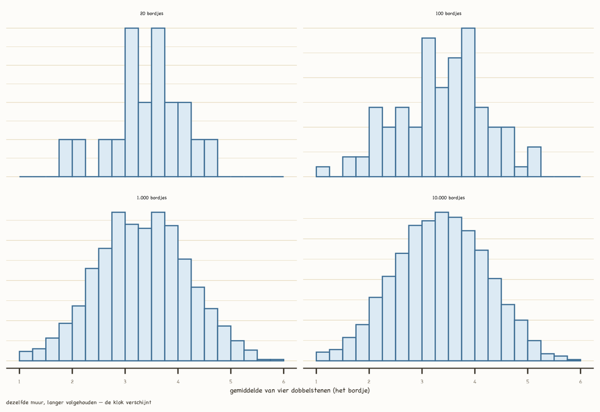

**Figuur 3.x (v1-steiger).** *De muur groeit: 20 → 100 → 1.000 → 10.000 bordjes — hier strooien: bórdjes (gemiddelden van vier worpen). De skyline wordt een klok. Getallen uit het waarheidsscript, seed 2026.*

Wat er dan gebeurt, zie je hierboven: het hobbelige turfsel van je keukentafel wordt een gladde heuvel, en die heuvel heeft een vorm. Een klok. Symmetrisch, dik in het midden, dunne staarten.

En hier komt het flauwe — echt, het is bijna een anticlimax: **die klok-vorm komt er altijd.** Het boeit niet hoe lelijk je populatie is. Dobbelstenen zijn plat als een dubbeltje verdeeld (elk getal even vaak), en tóch worden de bordjes een klok. Scheve populaties, rare populaties — als je grepen groot genoeg zijn, klokt de bordjes-muur. Wiskundigen doen hier heel gewichtig over en noemen het de *centrale limietstelling*; wij onthouden vooral wat het ons oplevert: we weten de vórm van de bordjes-muur al voordat we ook maar één keer geschud hebben. GROF: CLT-flauw-unit; naamgeving licht houden, geen bewijs, geen gewicht.

En één eigenschap van de klok is zó handig dat je hem nu alvast krijgt: **vrijwel alle bordjes — zo’n 95 van de 100 — hangen binnen twee lineaaltjes van het midden van de muur.** Wat dat lineaaltje van bordjes precies is, komt in de volgende paragraaf; onthou voor nu alleen het getal 95. Het duikt verderop nog een paar keer op, telkens in een andere jas. GROF — vuistregel ±2 lineaaltjes ≈ middelste 95; brug naar de 95%-afspraak in H5. Besloten 5-7.

## 4. Hoe ver zit een bordje ernaast?

GROF — van voelen naar rekenen. De twee vragen van het spel beantwoord:

**Beste gok voor een bordje?** Het gemiddelde van de ton. Bordjes klonteren rond het populatie-gemiddelde — je zag het zelf: drieënhalf.

**Gemiddelde gokfout op een bordje?** Kleiner dan bij losse individuen — dat zag je ook. Maar hoevéél kleiner? Hier is de enige nieuwe formule van dit hoofdstuk:

$$\sigma_{\bar{X}} = \frac{\sigma_X}{\sqrt{n}}$$

De gemiddelde gokfout van een bordje is de gemiddelde gokfout van een individu, gedeeld door de wortel van je greep-grootte. Dit getal heet de **standaardfout** (*standard error*, $SE$). Term-blokje. En herken het beeld: de *SD* uit hoofdstuk 1 was je lineaaltje voor individuen, de standaardfout is je lineaaltje voor bordjes — zelfde idee, korter lineaaltje.

En nu de theorie-check — vul hem in en je krijgt alles terug wat je aan de keukentafel al wist, je hoeft niks te leren:

GROF — berekenings-blok, Bens theorie-check-ritueel uit de Bib: σ = 15: bij n = 16 → 15/4 = 3,75. Bij n = 100 → 15/10 = 1,5 (grote greep, kalme bordjes — de grote slok van de olifant). Bij n = 4 → 15/2 = 7,5 (kleine greep, wilde bordjes — het kleine slokje dat ineens modder is). Grotere greep → deler groeit → gokfout krimpt. De formule ís de olifant.

**Voor wie verder wil — waarom de wórtel van $n$?**

De hoofdtekst is compleet zonder dit kader; sla het gerust over.

Waarom staat er een wortel, en niet gewoon $n$? Omdat onafhankelijke gokfouten elkaar deels opheffen: de ene greep zit erboven, de andere eronder. Hoofdstuk 1 vroeg je te onthouden dat kwadraat = oppervlakte is — de rest zou vanzelf komen. Dit is een stukje van die rest. Bij onafhankelijke fouten tellen namelijk niet de lengtes op, maar de pleintjes-oppervlaktes — dat is Pythagoras: de kruisterm valt weg. Eén greep heeft een foutoppervlakte van $\sigma^2$; $n$ onafhankelijke grepen samen $n \cdot \sigma^2$. De fout op de *som* is dan $\sqrt{n \cdot \sigma^2} = \sigma\sqrt{n}$, en delen door $n$ geeft de fout op het *gemiddelde*: $\sigma\sqrt{n}/n = \sigma/\sqrt{n}$. Daar komt de wortel vandaan. Let wel: dit werkt alleen als de grepen écht onafhankelijk zijn — fouten die op elkaar leunen, heffen elkaar niet op.

### Drie verdelingen — haal ze niet door elkaar

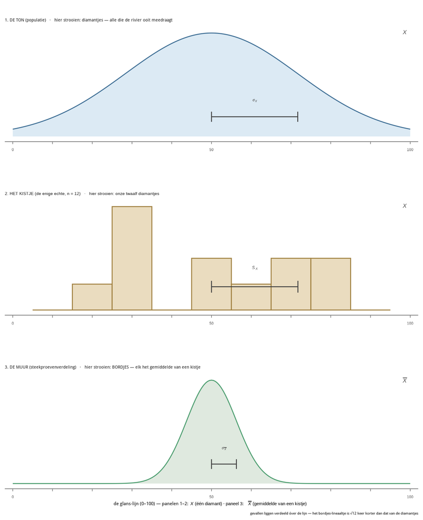

Figuur v1. De canonieke drie-verdelingen-unit, nu met de drie objecten van dit boek: de ton (breed) → het kistje (de enige echte — “een beetje zoals New York”) → de muur van bordjes (smal, geklokt). Individuen variëren méér dan gemiddelden.

## 5. Werk

Tienduizend keer vier dobbelstenen, elk gemiddelde bewaard. Er valt niets te installeren om dat te lézen — het is de truc, kaal. De simulatie zélf (schuiven met de greep-grootte, de klok zien komen, ook bij een scheve ton) doe je in het **grabbel-speeltje** — nul setup, gewoon in je browser. En rekenen mét R met je eigen data traint het R-oefenboek.

**▶ Open de grabbelton →** — grabbel zelf een muur van bordjes bij elkaar en zie de klok verschijnen.

Sier-regel-besluit (7-7, keuzes §1): in een simulatie-hoofdstuk mag één regel R-om-te-lézen blijven. Volledige simulatie-kiem: `03_oefenboek_kiemen/R_werk_uit_schetsen_2026-07-11.md`. Speeltje: `04_speeltjes/h3_grabbel.html`.

## 6. Sluiting

GROF — uitademing: De olifant vroeg hoe het meer smaakt, en het eerlijke antwoord is: dat weet niemand, nooit helemaal. Maar we weten nu iets dat bijna net zo goed is. We weten hoe goed één slok het meer vertelt — en dat grote slokken het beter vertellen dan kleine, en precies hoevéél beter: wortel-n beter.

Eén greep, de enige echte. En toch een uitspraak over de hele ton, mét een eerlijke foutmarge erbij.

Opmaat: beweging 1 is hiermee rond — we kunnen één variabele beschrijven én weten hoe zeker we ervan zijn. Wat we nog niet kunnen: twee variabelen tegelijk. Daarvoor moeten we terug naar het mos, waar twaalf diamantjes liggen te wachten. → H4.

## Open punten (grof → redactie-pas)

- **Meer-scène** stem-pas: nu functioneel geschreven; moet trager, meer Tellegen-lucht. De slotregel (“Het meer is álles”) mag misschien juist weg — laten steken.
- **Turf-strookje** ontwerpen (getallenlijn 1–6, kwart-stapjes, Caveat).
- **Beeldreeks bordjes-muur** (4 panelen: 20/100/1.000/altijd) — het visuele hart; handgetekend, skyline→klok.
- **Drie-verdelingen-figuur** (populatie/greep/bordjes onder elkaar).
- ✅ **Hoeveel z hier?** — besloten 5-7 avond (keuzes §1, z/normaal-plaatsing): hier alleen “korter lineaaltje” + vuistregel-95, geen tabellen/machinerie (werkboek-stof); rekenen in H5. Afgevinkt 7-7 (sweep blok 0).
- **CLT-naamgeving**: “centrale limietstelling” nu één keer genoemd, gewichtloos — genoeg? (Bens college-frame: “ze deden er altijd heel interessant over… het is gewoon een beetje flauw.”)
- **Dobbelsteen-getallen check**: σ van één dobbelsteen ≈ 1,71; SE bij n = 4 ≈ 0,85 — didactisch tonen of weglaten? Nu weggelaten (grof).
- **Volgorde H2/H3**: H3 gebruikt scheefheid (“boeit niet hoe lelijk je populatie is”) — H2 (vormen) moet dus echt vóór H3. Klopt met inhoudsopgave.
- **Object-ontologie (besloten 5-7):** schatkistje = steekproef · ton = populatie (het meer = verhaal-gedaante van de ton) · muur van bordjes = steekproevenverdeling. Brug-zin: “een greep uit de ton is een nieuw schatkistje.” **H5-cadeau:** bootstrap = “we hebben geen ton, alleen ons kistje — dus doen we alsof het kistje een ton is” (trekken mét teruglegging).
- ✅ **Beverdam — BESLOTEN (Ben, 5-7) en doorgevoerd** in §2: de rivier = de ton in beweging, de dam = het vangnet van de trekking; de vondst-scène van H1 is met terugwerkende kracht een steekproeftrekking. Selectie-teaser (wat zinkt, wat glipt erdoor) als zaadje genoteerd, uitwerken later.
- **Bib-borging**: het “gok een bordje”-frame + de meer-scène + de object-ontologie bestaan nu alleen in deze chat/schets — bij volgende molen-ronde als bron ingesten.
- ✅ **Werk-sectie → tabs (besloten 6-7), hier R vooraan:** de simulatie (replicate/sample) ís het verhaal — geen vinkje. JASP-tab zegt eerlijk wat daar wel/niet kan. Zie keuzes.md §1.

Een boek in wording je leest mee terwijl het zijn vorm vindt